# Differential Abundance Lab

David Clausen, Amy Willis, Sarah Teichman

2024-07-23

In this lab we’ll explore a dataset published by Wirbel et al. (2019). (https://www.nature.com/articles/s41591-019-0406-6).

This is a meta-analysis of case-control studies, meaning that Wirbel et al. collected raw sequencing data from studies other researchers conducted and re-analyzed it (in this case, they also collected some new data of their own).

Wirbel et al. published two pieces of data we’ll focus on today:

1. metadata giving demographics and other information about participants
2. a mOTU (metagenomic OTU) table

Although this lab works with mOTUs generated from shotgun data, all of the methods we consider will also work with OTUs generated from amplicon data, or other types of categories (genes, etc.) that we observe as counts from high-throughput sequencing.

In this analysis, we’re most interested in comparing microbial abundance in cases diagnosed with colorectal cancer to abundances in controls (without this diagnosis).

First let’s load libraries we’ll need.

## Exploring the data

We can start by loading the metadata table.

```r
data("wirbel_sample")
dim(wirbel_sample)
```

```
## [1] 566  14
```

```r
head(wirbel_sample)
```

```
##                             Sample_ID External_ID Age Gender BMI Country  Study
## CCIS00146684ST.4.0 CCIS00146684ST-4-0      FR-726  72      F  25     FRA FR-CRC
## CCIS00281083ST.3.0 CCIS00281083ST-3-0      FR-060  53      M  32     FRA FR-CRC
## CCIS02124300ST.4.0 CCIS02124300ST-4-0      FR-568  35      M  23     FRA FR-CRC
## CCIS02379307ST.4.0 CCIS02379307ST-4-0      FR-828  67      M  28     FRA FR-CRC
## CCIS02856720ST.4.0 CCIS02856720ST-4-0      FR-027  74      M  27     FRA FR-CRC
## CCIS03473770ST.4.0 CCIS03473770ST-4-0      FR-192  29      M  24     FRA FR-CRC
##                    Group Library_Size Age_spline.1 Age_spline.2 BMI_spline.1
## CCIS00146684ST.4.0   CTR     35443944  -0.19755428    0.7389621   1.18982420
## CCIS00281083ST.3.0   CTR     19307896  -0.08126128   -0.6818534  -1.40679307
## CCIS02124300ST.4.0   CTR     42141246  -2.17453529   -0.6818534   0.45476676
## CCIS02379307ST.4.0   CRC      4829533   0.67464323   -0.1490476   0.07698823
## CCIS02856720ST.4.0   CTR     34294675  -0.54643328    1.0941660   0.44793355
## CCIS03473770ST.4.0   CTR     20262319  -2.87229329   -0.6818534   0.95261443
##                    BMI_spline.2 Sampling
## CCIS00146684ST.4.0   -0.5606919   BEFORE
## CCIS00281083ST.3.0    2.0039136   BEFORE
## CCIS02124300ST.4.0   -0.6706035   BEFORE
## CCIS02379307ST.4.0    0.5384247   BEFORE
## CCIS02856720ST.4.0    0.1720525   BEFORE
## CCIS03473770ST.4.0   -0.6706035   BEFORE
```

Let’s see how many observations we have among cases (“CRC”) and controls (“CTR”)

```r
wirbel_sample %>%
  group_by(Group) %>%
  summarize(n = length(Group))
```

```
## # A tibble: 2 × 2
##   Group     n
##   <chr> <int>
## 1 CRC     278
## 2 CTR     288
```

We have data from studies in five different countries. How much from each study, you ask? Let’s find out!

```r
wirbel_sample %>%
  group_by(Country) %>%
  summarise(count = n())
```

```
## # A tibble: 5 × 2
##   Country count
##   <chr>   <int>
## 1 AUS       109
## 2 CHI       126
## 3 FRA       110
## 4 GER       120
## 5 USA       101
```

Now let’s load the mOTU table.

```r
data("wirbel_otu")
dim(wirbel_otu)
```

```
## [1] 566 845
```

```r
# let's check out a subset
wirbel_otu[1:5, 1:3]
```

```
##                    Streptococcus anginosus [ref_mOTU_v2_0004]
## CCIS00146684ST.4.0                                          0
## CCIS00281083ST.3.0                                          0
## CCIS02124300ST.4.0                                          2
## CCIS02379307ST.4.0                                          0
## CCIS02856720ST.4.0                                          1
##                    Enterobacteriaceae sp. [ref_mOTU_v2_0036]
## CCIS00146684ST.4.0                                         3
## CCIS00281083ST.3.0                                         0
## CCIS02124300ST.4.0                                         5
## CCIS02379307ST.4.0                                         5
## CCIS02856720ST.4.0                                       675
##                    Citrobacter sp. [ref_mOTU_v2_0076]
## CCIS00146684ST.4.0                                  0
## CCIS00281083ST.3.0                                  0
## CCIS02124300ST.4.0                                  0
## CCIS02379307ST.4.0                                  0
## CCIS02856720ST.4.0                                  0
```

We can see that this table has $566$ samples (just like the metadata) and $845$ mOTUs. Let’s save these mOTU names in a vector.

```r
mOTU_names <- colnames(wirbel_otu)
```

## Fitting a model

`radEmu` is a package that can be used to estimate log fold differences in the abundance of microbial taxa between levels of a covariate. In this analysis, the covariate that we are primarily interested in is whether a sample is from a case of colorectal cancer or a control. We will make control (“CTR”) the reference level:

```r
wirbel_sample$Group <- factor(wirbel_sample$Group, levels = c("CTR","CRC"))
```

While in general we would fit a model to all mOTUs, we are going to subset to some specific genera for the purposes of this lab. Let’s look at *Eubacterium*, *Porphyromonas*, *Faecalibacteria*, and *Fusobacterium* for now.

```r
chosen_genera <- c("Eubacterium", "Faecalibacterium", "Fusobacterium", "Porphyromonas")
mOTU_name_df <- data.frame(name = mOTU_names) %>%
  mutate(base_name = stringr::str_remove(mOTU_names, "unknown ") %>%
           stringr::str_remove("uncultured ")) %>%
  mutate(genus_name = stringr::word(base_name, 1))
restricted_mOTU_names <- mOTU_name_df %>%
  filter(genus_name %in% chosen_genera) %>%
  pull(name)
```

While we would generally fit a model using all of our samples, for this lab we are only going to consider data from a case-control study from China.

```r
ch_study_obs <- which(wirbel_sample$Country %in% c("CHI"))
```

Next, we want to confirm that all samples have at least one non-zero count across the categories we’ve chosen and that all categories have at least one non-zero count across the samples we’ve chosen.

```r
small_Y <- wirbel_otu[ch_study_obs, restricted_mOTU_names]
sum(rowSums(small_Y) == 0) # no samples have a count sum of 0
```

```
## [1] 0
```

```r
sum(colSums(small_Y) == 0) # one category has a count sum of 0
```

```
## [1] 1
```

```r
category_to_rm <- which(colSums(small_Y) == 0)
small_Y <- small_Y[, -category_to_rm]
sum(colSums(small_Y) == 0)
```

```
## [1] 0
```

The function that we use to fit our model is called `emuFit`. It can accept your data in various forms, and here we will show how to use it with data frames as input. You can also input `phyloseq` objects!

One version of inputs to `emuFit` are

- `formula`: This is a formula telling radEmu what predictors to use. We are using Group, which is an indicator for case (CRC) vs control (CTR).
- `data`: A dataframe containing information on our predictors. Recall that here we’re only looking observations from the Chinese study.
- `Y`: A matrix or dataframe containing our observed abundance data (e.g., counts or depth measurements). The rows give the observations (samples), and the columns give the categories (taxa/mOTUs). Here we are only considering the observations from the Chinese study and the specific genera that we chose.

there is also an important optional argument:

- `run_score_tests`: A logical value denoting whether or not to run score tests. Score tests are awesome in their error rate control (including with small sample sizes; though of course larger sample sizes always give better power), but require refitting the model, so can require some compute time.

```r
ch_fit <- emuFit(formula = ~ Group,
                 data = wirbel_sample[ch_study_obs, ],
                 Y = small_Y,
                 run_score_tests = FALSE)
```

Let’s check out what this object looks like!

```r
ch_fit
```

```
##
## Call:
## emuFit(Y = small_Y, formula = ~Group, data = wirbel_sample[ch_study_obs,
##     ], run_score_tests = FALSE)
##
##
## Coefficient estimates with the largest magnitudes:
##    covariate                                                category
## 24  GroupCRC               unknown Porphyromonas [meta_mOTU_v2_5431]
## 8   GroupCRC     Fusobacterium sp. oral taxon 370 [ref_mOTU_v2_1403]
## 19  GroupCRC                 Fusobacterium varium [ref_mOTU_v2_4311]
## 12  GroupCRC                Porphyromonas somerae [ref_mOTU_v2_2101]
## 9   GroupCRC         Fusobacterium gonidiaformans [ref_mOTU_v2_1404]
## 13  GroupCRC                Porphyromonas uenonis [ref_mOTU_v2_2102]
## 3   GroupCRC Fusobacterium nucleatum s. nucleatum [ref_mOTU_v2_0777]
```

[output cut: 34 more lines]

```
## To obtain the entire coefficient table, use the command `emuFit_object$coef`.
```

The way to access estimated coefficients and confidence intervals from the model is with `ch_fit$coef`. We’ll save the estimates in a vector

```r
ch_fit$coef[1, ]
```

```
##   covariate                                                category
## 1  GroupCRC Fusobacterium nucleatum s. vincentii [ref_mOTU_v2_0754]
##   category_num estimate        se      lower    upper score_stat pval
## 1            1 1.486379 0.8966329 -0.2709896 3.243747         NA   NA
```

```r
radEmu_est <- ch_fit$coef$estimate
```

Let’s interpret this parameter! Here `radEmu` is estimating that the log fold difference in *Fusobacterium nucleatum s. vincentii [ref_mOTU_v2_0754]* associated with cases of CRC (as opposed to controls) minus the *typical* log fold difference associated with cases versus controls across all $46$ mOTUs in this analysis is $1.486$.

By default `radEmu` estimates this type of parameter, in which we compare the log fold difference in one mOTU to the *typical* (approximately the median) log fold difference in all mOTUs. However, `radEmu` is flexible and will let you define other types of parameters. We can instead compare all log fold differences to the log fold difference for a specific mOTU.

Let’s find the mOTU that is present in the highest proportion of samples from the Chinese cohort, and use this as a reference mOTU.

```r
num_present <- colSums(small_Y > 0)
ref_num <- which.max(num_present)
ref_num
```

```
## Faecalibacterium prausnitzii [ref_mOTU_v2_4875]
##                                              22
```

```r
ch_fit_ref <- emuFit(formula = ~ Group,
                     data = wirbel_sample[ch_study_obs, ],
                     Y = small_Y,
                     run_score_tests = FALSE,
                     # set our "constraint" i.e. choose our reference mOTU
                     constraint_fn = function(x) {x[ref_num]},
                     constraint_grad_fn = function(x) {
                       grad <- rep(0, length(x))
                       grad[ref_num] <- 1
                       return(grad) },
                     constraint_param = NA)
ch_fit_ref$coef[1, ]
```

```
##   covariate                                                category
## 1  GroupCRC Fusobacterium nucleatum s. vincentii [ref_mOTU_v2_0754]
##   category_num estimate        se      lower    upper score_stat pval
## 1            1 1.867323 0.9394841 0.02596818 3.708678         NA   NA
```

Now we will interpret our parameter slightly differently. Here `radEmu` is estimating that the log fold difference in *Fusobacterium nucleatum s. vincentii [ref_mOTU_v2_0754]* associated with cases of CRC (as opposed to controls) minus the log fold difference in *Faecalibacterium prausnitzii [ref_mOTU_v2_4875]* associated with cases is $1.867$.

We can compare the estimates from these two runs of `radEmu`.

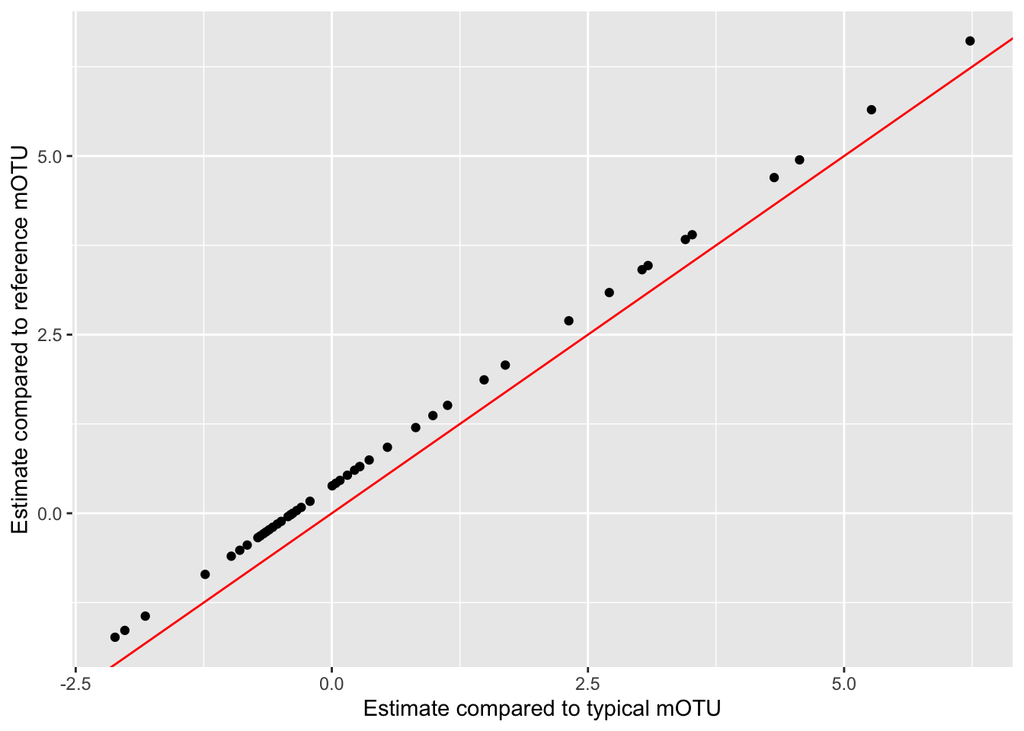

```r
data.frame(typical_est = ch_fit$coef$estimate,
           reference_est = ch_fit_ref$coef$estimate) %>%
  ggplot(aes(x = typical_est, y = reference_est)) +
  geom_point() +
  geom_abline(aes(intercept = 0, slope = 1), color = "red") +
  labs(x = "Estimate compared to typical mOTU",
       y = "Estimate compared to reference mOTU")
```

The $x = y$ line is shown in red. Here we can see that changing the constraint in `radEmu` shifts all of the estimates up or down but does not change their order in terms of estimated log fold differences. Let’s switch back to the model that we fit first, in which we compare each log fold difference to the typical log fold difference across all mOTUs, and look closer at our results.

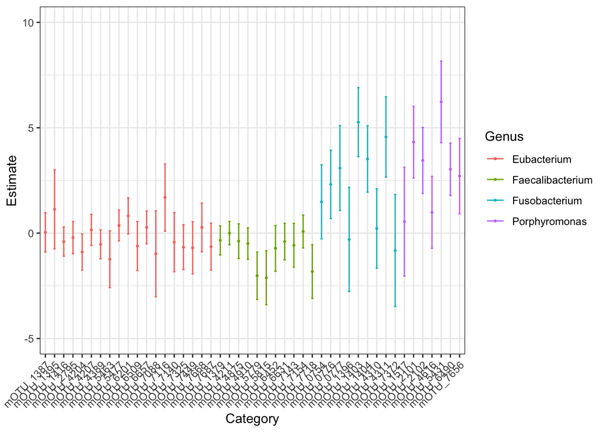

```r
ch_df <- ch_fit$coef %>%
  mutate(Genus = (mOTU_name_df %>%
                    filter(genus_name %in% chosen_genera) %>%
                    pull(genus_name))[-category_to_rm]) %>%
  # add genus name to output from emuFit
  mutate(cat_small = stringr::str_remove(paste0("mOTU_",
                                                stringr::str_split(category, 'mOTU_v2_', simplify = TRUE)[, 2]),
                                         "\\]")) %>%
  mutate(cat_small = factor(cat_small, levels = cat_small[order(Genus)]))
  # reorder mOTU categories by genus

ggplot(ch_df) +
  geom_point(aes(x = cat_small, y = estimate,color = Genus), size = .5) +
  geom_errorbar(aes(x = cat_small, ymin = lower, ymax = upper, color = Genus), width = .25) +
  theme_bw() +
  theme(axis.text.x = element_text(angle = 45, hjust = 1)) +
  labs(x = "Category",
       y = "Estimate") +
  coord_cartesian(ylim = c(-5, 10))
```

Interestingly, we estimate a mOTU *unknown Eubacterium [meta_mOTU_v2_7116]* assigned to Eubacteria to have a much higher ratio of abundance (comparing CRC group to control) than is typical across the Eubacteria mOTUs we included in this analysis.

The confidence interval for this effect does not include zero – but (!!!) the kind of confidence interval that is returned by default by emuFit is not extremely reliable when counts are very skewed or sample size is small-to-moderate.

To investigate further, let’s run a robust score test, which is more reliable in these settings (but also takes more time because apparently we can’t have nice things). For comparison, we’ll also test the mOTU *Fusobacterium nucleatum s. nucleatum [ref_mOTU_v2_0777]*, which we also estimate to have a much larger ratio of concentrations across groups than is typical among the taxa we included in this model fit.

To set up this test, we can again run `emuFit`, giving it the fitted values that it’s already found:

- `formula`, `data` and `Y` are as before
- `B` is our previous fitted object (the output of `emuFit`)
- `test_kj` a dataframe listing the indices of the parameters (in `ch_fit$B`) that we want to test. Below we show how to identify these, but `j = 3` is F. nucleatum and `j = 36` is the Eubacterium meta mOTU.

```r
taxa_to_test <- which(colnames(small_Y) %in%
                        c("unknown Eubacterium [meta_mOTU_v2_7116]",
                          "Fusobacterium nucleatum s. nucleatum [ref_mOTU_v2_0777]"))
ch_fit$B %>% rownames
```

```
## [1] "(Intercept)" "GroupCRC"
```

```r
covariate_to_test <- which("GroupCRC" == ch_fit$B %>% rownames)
two_robust_score_tests <- emuFit(formula = ~ Group,
                                 data = wirbel_sample[ch_study_obs, ],
                                 B = ch_fit,
                                 test_kj = data.frame(k = covariate_to_test,
                                                      j = taxa_to_test),
                                 Y = small_Y)
```

Let’s take a look at the test output.

```r
two_robust_score_tests$coef[taxa_to_test, c("covariate", "category", "estimate", "pval")]
```

```
##    covariate                                                category estimate
## 3   GroupCRC Fusobacterium nucleatum s. nucleatum [ref_mOTU_v2_0777] 3.086405
## 36  GroupCRC                 unknown Eubacterium [meta_mOTU_v2_7116] 1.692993
##          pval
## 3  0.07423418
## 36 0.30168301
```

The *Fusobacterium nucleatum* mOTU has a robust score test p-value of 0.07, while the *unknown Eubacterium* mOTU has a robust score test p-value of 0.30. Does this make sense? Let’s investigate further by looking at the *Eubacterium* mOTU counts by Group.

```r
data.frame(counts = wirbel_otu[ch_study_obs, "unknown Eubacterium [meta_mOTU_v2_7116]"],
           group = wirbel_sample$Group[ch_study_obs]) %>%
  mutate(eubact_present = counts > 0) %>%
  group_by(group, eubact_present) %>%
  summarise(count = n())
```

```
## # A tibble: 3 × 3
## # Groups:   group [2]
##   group eubact_present count
##   <fct> <lgl>          <int>
## 1 CTR   FALSE             54
## 2 CRC   FALSE             71
## 3 CRC   TRUE               1
```

We only detect this meta-mOTU in a single sample in the Chinese study cohort! So, yes – it makes sense that our test returns a relatively large p-value. Good job, robust score test!

Now lets look at *F. nucleatum*.

```r
data.frame(counts = wirbel_otu[ch_study_obs,
                               "Fusobacterium nucleatum s. nucleatum [ref_mOTU_v2_0777]"],
           group = wirbel_sample$Group[ch_study_obs]) %>%
  mutate(fuso_present = counts > 0) %>%
  group_by(group, fuso_present) %>%
  summarise(count = n())
```

```
## # A tibble: 4 × 3
## # Groups:   group [2]
##   group fuso_present count
##   <fct> <lgl>        <int>
## 1 CTR   FALSE           53
## 2 CTR   TRUE             1
## 3 CRC   FALSE           59
## 4 CRC   TRUE            13
```

This also makes sense given what we found – *F. nucleatum* shows up in a sizeable minority of CRC cases, whereas Wirbel et al detect it in only one control participant.

We could run robust score tests for every taxon in this analysis, but it will take ~3 minutes to run. Therefore we do not evaluate it here (note the argument in the code chunk `eval = FALSE`.

```r
test_all <- emuFit(formula = ~ Group,
                   data = wirbel_sample[ch_study_obs, ],
                   B = ch_fit,
                   Y = small_Y,
                   run_score_tests = TRUE)
```

However, we ran these robust score tests and saved the coefficient table for you, which we can load in here.

```r
radEmu_coef <- read.csv("radEmu_coef.csv")
radEmu_pvals <- radEmu_coef$pval
```

## FastEmu

What if we want to analyze all $845$ mOTUs for the Chinese cohort? While the estimation procedure in `radEmu` can handle this many otus, the score tests will run pretty slowly, because the more categories in our model, the more parameters we have to estimate for each score test, and the longer this process will take.

Luckily, we can approximate the robust score tests with a companion method to `radEmu`, `fastEmu`!

First we need to get rid of all of the mOTUs in the full dataset with only zero counts across the Chinese study cohort.

```r
bigger_Y <- wirbel_otu[ch_study_obs, ]
categories_to_rm <- which(colSums(bigger_Y) == 0)
bigger_Y <- bigger_Y[, -categories_to_rm]
dim(bigger_Y)
```

```
## [1] 126 758
```

We are left with $758$ mOTUs. Again, we will run robust score tests for our two mOTUs of interest

```r
taxa_to_test <- which(colnames(bigger_Y) %in%
                        c("unknown Eubacterium [meta_mOTU_v2_7116]",
                          "Fusobacterium nucleatum s. nucleatum [ref_mOTU_v2_0777]"))
```

`fastEmu` has pretty similar sytax to radEmu, except that we will also specify a small set of mOTUs as the comparison set (this changes the interpretation of our parameter, it is now the log fold difference of the mOTU of interest relative to the typical log fold difference in the comparison set. Here we choose the set of mOTUs in our previous model as the comparison set.)

This will take ~1 minute to run.

```r
fastEmu_res <- fastEmuTest(formula = ~ Group,
                           data = wirbel_sample[ch_study_obs, ],
                           Y = bigger_Y,
                           # set comparison set to be set from earlier analysis
                           constraint_cats = which(colnames(bigger_Y) %in% colnames(small_Y)),
                           test_kj = data.frame(k = 2, j = taxa_to_test),
                           # set lower tolerances than default
                           # this means the estimates won't be *quite* as precise,
                           # but it will run faster, which we want in this lab
                           tolerance = 5e-3,
                           constraint_tol = 1e-3)
```

Now we have estimates for all $758$ mOTUs, and robust score test results for the same mOTUs as earlier. The difference is that `radEmu` would take much longer to run these robust score tests in the presence of $758$ mOTUS.

```r
fastEmu_res$coef[taxa_to_test, c("covariate", "category", "estimate", "pval")]
```

```
##     covariate                                                category estimate
## 68   GroupCRC Fusobacterium nucleatum s. nucleatum [ref_mOTU_v2_0777] 3.086405
## 613  GroupCRC                 unknown Eubacterium [meta_mOTU_v2_7116] 1.692993
##           pval
## 68  0.07428192
## 613 0.30168301
```

The results from these two score tests are nearly identical to the `radEmu` model.

We recommend using `fastEmu` over `radEmu` when running differential abundance analyses for very large datasets. It was motivated by the problem of estimating and testing log fold differences in abundance in genes from shotgun data.

## Fitting other models

While we like `radEmu`, it isn’t the only differential abundance testing method that you can use. Let’s see how these results relate to differential abundance methods implemented in other software packages. Note that each software will be testing different hypotheses with different models and different estimators.

### ALDEx2

`ALDEx2` is built to analyze RNA-seq data but can be used for microbiome data as well.

To start, we need to get our data into a form that `ALDEx2` will accept.

```r
covariate <- wirbel_sample$Group[ch_study_obs]
# aldex doesn't like a factor, so we will convert the covariate to TRUE/FALSE
covariate_boolean <- ifelse(covariate == "CRC", TRUE, FALSE)
X <- cbind(1, covariate_boolean)
# swap rows and columns (ALDEx2 requires samples as columns)
small_Y_transpose <- t(small_Y)
```

Now we’re ready to run `ALDEx2`.

```r
aldex_clr <- aldex.clr(small_Y_transpose, X, mc.samples=500, denom="all", verbose=FALSE)
aldex_res <- aldex.glm(clr = aldex_clr, X)
```

```
## |------------(25%)----------(50%)----------(75%)----------|
```

```r
aldex_est <- aldex_res$`covariate_boolean:Est`
aldex_pvals <- aldex_res$`covariate_boolean:pval`
```

### ANCOM-BC2

`ANCOM-BC2` is a differential abundance method built specifically for microbiome data, which accounts for sample-specific and taxon-specific detection effects in HTS data.

`ANCOM-BC2` requires certain data formats. One option is a `TreeSummarizedExperiment` object.

We can start by making a `TreeSummarizedExperiment` object with our data.

```r
tse_data <- TreeSummarizedExperiment(assays = list("counts" = t(small_Y)),
                                     colData = data.frame(Group = covariate))
```

Now we can run `ANCOM-BC2`.

```r
ancom_res <- ancombc2(data = tse_data,
                      assay_name = "counts",
                      fix_formula = "Group",
                      prv_cut = 0)
ancom_est <- ancom_res$res$lfc_GroupCRC
ancom_pvals <- ancom_res$res$p_GroupCRC
ancom_est
```

```
##  [1]  0.16373365  1.19652305  0.04060559 -0.23065000  0.15289141  1.40050682
##  [7]  0.19004044  2.28428584          NA -0.31347405 -2.99964460          NA
## [13]          NA  0.17884789 -0.71800648  0.15190563  0.11738582 -0.39378420
## [19]  2.06219214 -1.06315453  0.91920373 -0.32880285 -0.56729875          NA
## [25] -0.35209935  0.64238864 -0.60765029 -0.34977914  0.81428482 -0.64506872
## [31]          NA -0.21416816 -0.28259923  0.44323747  1.43317914          NA
## [37] -0.03471416  0.14006108  0.85475866 -0.36034731 -1.20220199 -0.04951577
## [43]  0.83880106 -0.30213112 -0.02511839 -0.07165597
```

When we look at `ancom_est` we can see six estimates are recorded as `NA`. This is because `ANCOM-BC2` cannot compute estimates and p-values for mOTUs that show separation, i.e. they only have non-zero counts in one of the covariate levels. This is one disadvantage of `ANCOM-BC2`.

### DESeq2

`DESeq2` is another method that was built for RNA-seq data, but is commonly used for microbiome differential abundance analyses.

`DESeq2` cannot run with default settings if all mOTUs have at least one zero. Let’s check on this condition in our data.

```r
mOTUs_no_zero <- colSums(small_Y == 0) == 0
which(mOTUs_no_zero)
```

```
## named integer(0)
```

```r
# named integer(0) is what R says when it can't find any indices that are equal to TRUE
```

Because there are no mOTUs in our data that fit this criteria, we will need to add pseudocounts. We will add a count of $1$ to each observation in our count matrix (note: there are different ways in which people choose to use pseudocounts. This is why we try to avoid them in our methods).

```r
Y_pseudo <- small_Y_transpose + 1
dds <- DESeqDataSetFromMatrix(countData = Y_pseudo,
                              colData = wirbel_sample[ch_study_obs, ],
                              design = ~ Group)
deseq_res <- DESeq(dds)
deseq_results <- results(deseq_res)
deseq_est <- deseq_results$log2FoldChange/log(2)
# note, we divide by log base 2 fold change by log 2 so that it will be on the same scale as the log fold changes from other methods that use a natural log
deseq_pvals <- deseq_results$pvalue
```

## Comparing across methods

Now that we’ve run each of these methods, let’s compare the estimates and p-values. We’ll start with the estimates.

```r
data.frame(radEmu_est, aldex_est, ancom_est, deseq_est) %>%
  cor(use = "complete.obs")
```

```
##            radEmu_est aldex_est ancom_est deseq_est
## radEmu_est  1.0000000 0.6808670 0.5907504 0.7642676
## aldex_est   0.6808670 1.0000000 0.4507389 0.8304540
## ancom_est   0.5907504 0.4507389 1.0000000 0.3751911
## deseq_est   0.7642676 0.8304540 0.3751911 1.0000000
```

Here we can see relatively strong agreement between these four methods. `radEmu` estimates are most similar to those from `DESeq2`

Next, we can compare the p-values.

```r
pval_df <- data.frame(mOTU = names(small_Y),
  radEmu_pvals, aldex_pvals, ancom_pvals, deseq_pvals)
pval_df %>% dplyr::select(contains("pval")) %>%
  cor(use = "complete.obs")
```

```
##              radEmu_pvals aldex_pvals ancom_pvals deseq_pvals
## radEmu_pvals   1.00000000   0.3208642  0.08645726   0.3818563
## aldex_pvals    0.32086424   1.0000000  0.14202496   0.3235683
## ancom_pvals    0.08645726   0.1420250  1.00000000   0.1068269
## deseq_pvals    0.38185633   0.3235683  0.10682694   1.0000000
```

We see much lower correlation between p-values. This makes sense, because each method has different testing procedures.

Finally, we can check out which mOTUs each method highlight as being the most significant

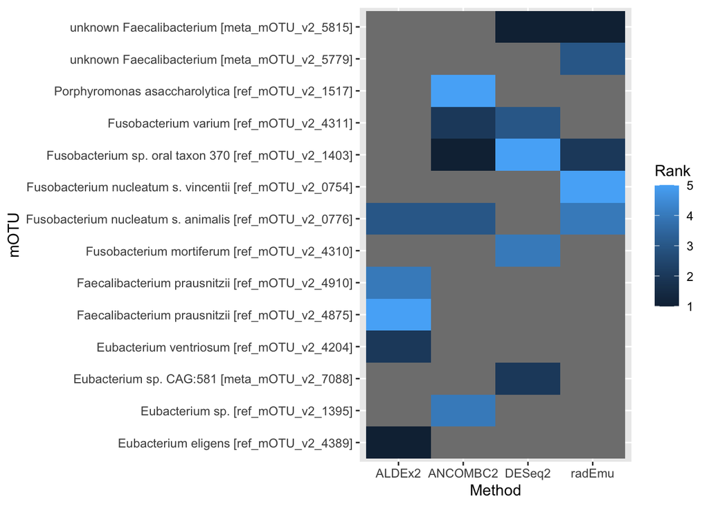

```r
pval_df %>%
  mutate(radEmu = rank(radEmu_pvals),
         ALDEx2 = rank(aldex_pvals),
         ANCOMBC2 = rank(ancom_pvals),
         DESeq2 = rank(deseq_pvals)) %>%
  filter(radEmu < 6 | ALDEx2 < 6 | ANCOMBC2 < 6 | DESeq2 < 6) %>%
  dplyr::select(-contains("pval")) %>%
  pivot_longer(cols = 2:5, names_to = "method", values_to = "rank") %>%
  mutate(rank = ifelse(rank > 5, NA, rank)) %>%
  ggplot(aes(y = mOTU, x = method, fill = rank)) +
  geom_tile() +
  labs(x = "Method", fill = "Rank")
```

From this plot we can see that there are $14$ mOTUs that have one of the top five smallest p-values for one or more method. Out of these, $10$ are only in the top five for one method, $2$ are in the top five for two methods, and $2$ are in the top five for three methods. If we were using these differential abundance methods for hypothesis generation, to find the mOTUs with the most evidence against the null hypotheses of no differential abundance, we would find some overlapping mOTUs across methods.

## Conclusions

In this lab, we’ve compared several differential abundance methods: `radEmu`, `fastEmu`, `ALDEx2`, `ANCOM-BC2`, and `DESeq2`. We’ve seen that while there are strong correlations between the log fold difference estimates from each of these methods, there are weaker correlations between the p-values and different conclusions in terms of the most differentially abundant mOTUs. Each of these methods (and the many differential abundance methods that we didn’t consider here) have pros and cons. An incomplete list includes the following:

- `radEmu`
  - pros: has Type I error rate control in many situations, handles sparsity well
  - cons: robust score tests are slow, especially in datasets with a large number of categories (taxa, genes, etc.)
- `fastEmu`
  - pros: inherits `radEmu` pros, is much faster than `radEmu` (especially with a large number of categories)
  - cons: requires a comparison subset of categories, it still slower than several other methods
- `ALDEx2`
  - pros: has Type I error rate control in many situations, faster than `radEmu` to test all categories
  - cons: is pretty conservative (lower power)
- `ANCOM-BC2`
  - pros: high power, faster than `radEmu` to test all categories
  - cons: fails to control Type I error rate in some situations, can’t handle data separation (a common consequence of sparsity)
- `DESeq2`
  - pros: faster than `radEmu` to test all categories
  - cons: fails to control Type I error in some situations, requires pseudocounts in some settings

Check out the documentation for each of these packages for more information and more practice using them. Although this example uses a single binary covariate, each of these methods can be run with more complex regression models.